# msn_graph_walk.R

zhian

Mon Apr 27 12:20:38 2015

# Demonstrating Graph Walking algorithms in R

In version 2.0, poppr introduces the option to include reticulation in minimum spanning networks. This is essential for clonal organisms as mutation has a much higher influence on genetic diversity as opposed to meiotic processes.

In this examle, I will utilize *P. ramorum* data from Kamvar et al. (2015). The source should be downloaded with the following command:

```r
devtools::install_github("zkamvar/Sudden_Oak_Death_in_Oregon_Forests/PramCurry")
```

After you’ve downloaded the package, you can load the library and the data.

```r
library("PramCurry")
```

```r
library("poppr")
library("igraph")
data(for2nur)
data(comparePal)
```

Below are some functions we need to convert the data to the proper format as well as some helper functions from the PramCurry package.

```r
# Conversion from adegenet 1.4 to 2.0
data_replacer <- function(x){
  # manipulate your data here
  if (x@type == "codom"){
    xtab <- x@tab
    newtab <- as.integer(x@tab * x@ploidy)
    x@tab <- matrix(newtab, nrow = nrow(xtab), ncol = ncol(xtab),
                    dimnames = dimnames(xtab))
    x@ploidy <- rep(x@ploidy, nrow(x@tab))
    names(x@loc.names) <- NULL
    rownames(x@tab) <- x@ind.names
    names(x@all.names) <- x@loc.names
    colnames(x@tab) <- unlist(lapply(x@loc.names,
                                     function(i) paste(i, x@all.names[[i]],
                                                       sep = ".")),
                              use.names = FALSE)
    levels(x@loc.fac) <- x@loc.names
    names(x@loc.nall) <- x@loc.names
  }

  if (!is.null(x@pop)){
    levels(x@pop) <- x@pop.names
  }
  if ("genclone" %in% class(x)){
    x@strata <- x@hierarchy
    x@hierarchy <- NULL
  } else {
    x@hierarchy <- NULL
    x@strata    <- NULL
  }
  return(x)
}

# These functions are from Kamvar et al. 2015
make_node_list <- function(clusts, pal, cutoff = 3){
  PAL <- match.fun(pal)
  clustPal  <- table(clusts$membership)
  theClusts <- clustPal > 3
  clustOrder <- order(clustPal, decreasing = TRUE)
  clustPal[clustOrder][theClusts[clustOrder]]   <- PAL(sum(theClusts))
  clustPal[clustOrder][!theClusts[clustOrder]]  <- gray.colors(sum(!theClusts))
  nodeList <- lapply(1:length(clustPal), function(x) which(clusts$membership == x))
  names(nodeList) <- clustPal
  return(nodeList)
}

clust_cutoff <- function(clusts, cutoff = 3){
  table(clusts$membership) > 3
}
```

### Data setup

Conversion

```r
for2nur <- data_replacer(for2nur)
setPop(for2nur) <- ~SOURCE/STATE
for2nur
```

```
##
## This is a genclone object
## -------------------------
## Genotype information:
##
##     98 multilocus genotypes
##    729 diploid individuals
##      5 codominant loci
##
## Population information:
##
##      3 strata - SOURCE YEAR STATE
##      9 populations defined - Nursery_CA Nursery_OR JHallCr_OR ...
## Winchuck_OR ChetcoMain_OR PistolRSF_OR
```

Repeat lengths are necessary:

```r
newReps <- other(for2nur)$REPLEN
(newReps[3] <- 4) # Tetranucleotide repeat
```

```
## [1] 4
```

```r
(newReps <- fix_replen(for2nur, newReps))
```

```
##  PrMS6A1  Pr9C3A1 PrMS39A1 PrMS45A1 PrMS43A1
##  3.00000  2.00000  3.99999  4.00000  4.00000
```

### Calculating the minimum spanning networks

We will create two msns: one with no reticulations (`nf.msn.noties`) and one with reticulations (`nf.msn.ties`). these will be analyzed with the infomap community detection algorithm and then the memberships will be compared to the observed populations.

```r
# No reticulations in the network.
nf.msn.noties <- bruvo.msn(for2nur, replen = newReps, showplot = FALSE)
# Adding reticulations
nf.msn.ties <- bruvo.msn(for2nur, replen = newReps, include.ties = TRUE,
                         showplot = FALSE)
```

Now, we are going to use the igraph function `infomap.community`. Basically, it will send random walkers through the graph and see where they spend the most time. It considers edge weights and vertex weights. For vertex weights, we are setting them to be the number of samples in each vertex.

```r
clusts.noties <- infomap.community(nf.msn.noties$graph, nb.trials = 1e3,
                                   v.weights = V(nf.msn.noties$graph)$size)
clusts.ties <- infomap.community(nf.msn.ties$graph, nb.trials = 1e3,
                                 v.weights = V(nf.msn.ties$graph)$size)
```

The membership of each sample is matched here.

```r
members.ties <- clusts.ties$membership[match(mlg.vector(for2nur), mlgFromString(V(nf.msn.ties$graph)$label))]
members.noties <- clusts.noties$membership[match(mlg.vector(for2nur), mlgFromString(V(nf.msn.noties$graph)$label))]
```

Now, we are comparing the memberships vs. the populations

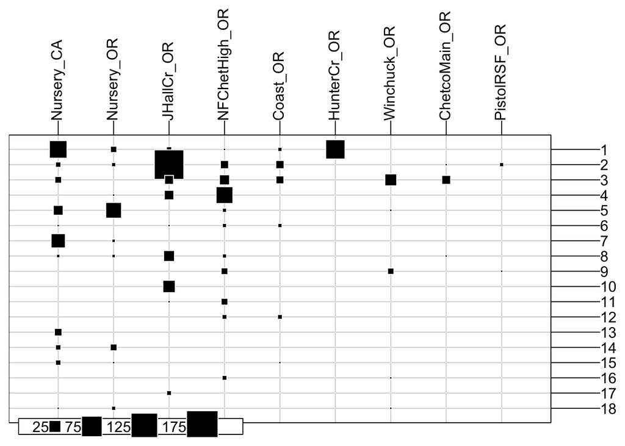

```r
table.value(table(members.ties, pop(for2nur)), col.labels = popNames(for2nur))
```

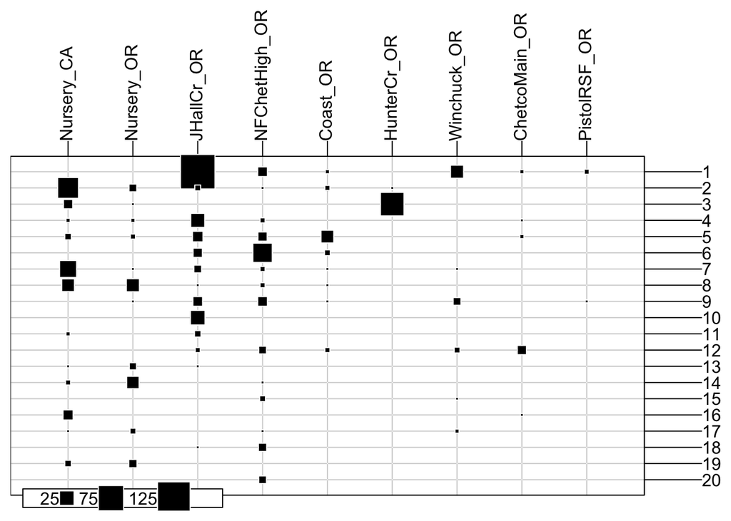

```r
table.value(table(members.noties, pop(for2nur)), col.labels = popNames(for2nur))
```

One other thing to look at is the sizes of the communities. With a clonal pathogen, we expect to see larger communities.

```r
sizes(clusts.ties)
```

```
## Community sizes
##  1  2  3  4  5  6  7  8  9 10 11 12 13 14 15 16 17 18
## 11  7 13  7  8  6  5  3  5  6  4  3  3  4  4  3  2  4
```

```r
sizes(clusts.noties)
```

```
## Community sizes
##  1  2  3  4  5  6  7  8  9 10 11 12 13 14 15 16 17 18 19 20
##  5  5  6  4  5  7  5  7  7  5  4  7  3  4  3  4  6  4  4  3
```

What we are seeing is that the reticulations allow for more genotypes to be clustered together because there are more meaningful connections.

Below, we will see what the graphs look like with and without ties. ### with ties

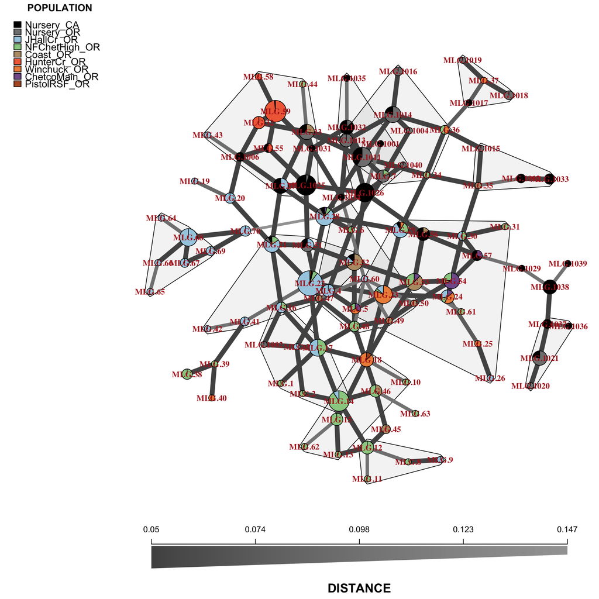

```r
nf.msn <- nf.msn.ties
clusts <- clusts.ties
mypal <- ifelse(length(unique(clusts$membership)) < 14,
                RColorBrewer::brewer.pal(x, "Paired"),
                colorRampPalette("black"))
nodeList <- make_node_list(clusts, mypal, cutoff = 3)
theClusts <- clust_cutoff(clusts, 3)

goodSeed <- 6
thisPal <- function(x) comparePal[nf.msn$populations]

set.seed(goodSeed)
MASTER <- get_layout(nf.msn$graph, LAYOUT = layout.fruchterman.reingold)
plot_poppr_msn(for2nur, nf.msn, gad = 10, palette = thisPal, mlg = TRUE,
               layfun = MASTER, nodebase = 1.75, vertex.label.font = 2,
               quantiles = FALSE, #inds = "none",
               vertex.label.color = "firebrick",
               mark.groups = nodeList[theClusts],
               mark.border = names(nodeList)[theClusts],
               mark.col = transp(names(nodeList)[theClusts], 0.05),
               mark.expand = 2,
               mark.shape = 0)
```

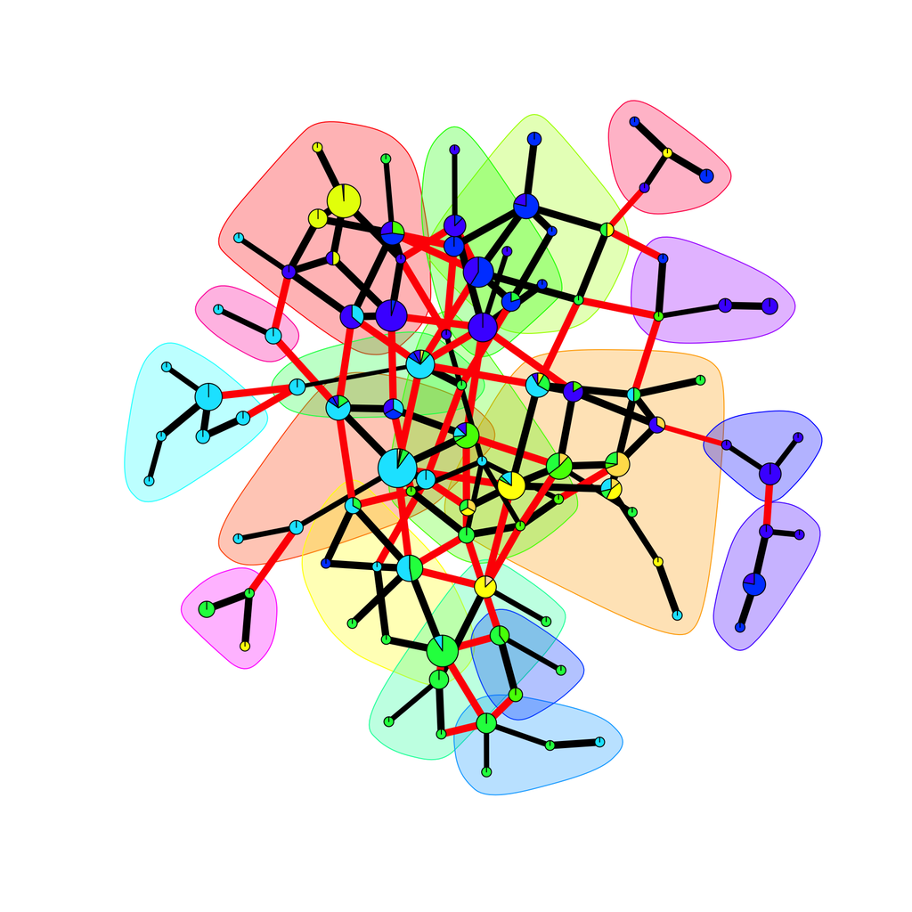

```r
plot(clusts, nf.msn$graph, vertex.size = log(V(nf.msn$graph)$size, 1.75) + 3,
     vertex.label = NA, layout = MASTER)
```

### without ties

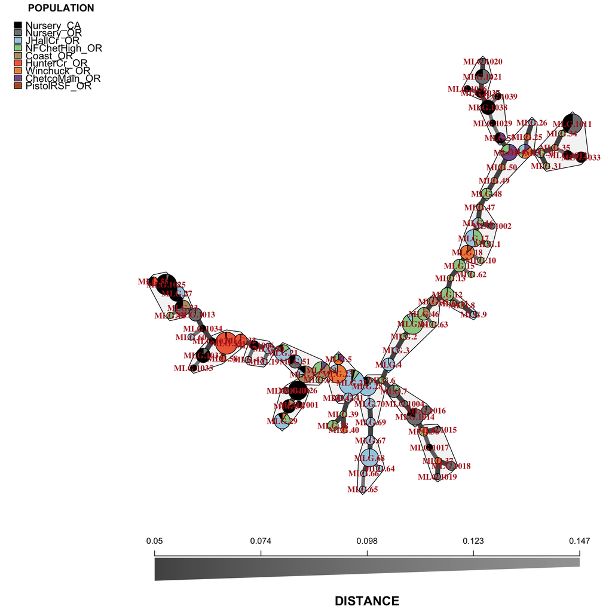

```r
nf.msn <- nf.msn.noties
clusts <- clusts.noties
mypal <- ifelse(length(unique(clusts$membership)) < 14,
                RColorBrewer::brewer.pal(x, "Paired"),
                colorRampPalette("black"))
nodeList <- make_node_list(clusts, mypal, cutoff = 3)
theClusts <- clust_cutoff(clusts, 3)

goodSeed <- 6
thisPal <- function(x) comparePal[nf.msn$populations]
set.seed(goodSeed)
MASTER <- get_layout(nf.msn$graph, LAYOUT = layout.auto)
plot_poppr_msn(for2nur, nf.msn, gad = 10, palette = thisPal, mlg = TRUE,
               layfun = MASTER, nodebase = 1.75, vertex.label.font = 2,
               quantiles = FALSE, #inds = "none",
               vertex.label.color = "firebrick",
               mark.groups = nodeList[theClusts],
               mark.border = names(nodeList)[theClusts],
               mark.col = transp(names(nodeList)[theClusts], 0.05),
               mark.expand = 2,
               mark.shape = 0)
```

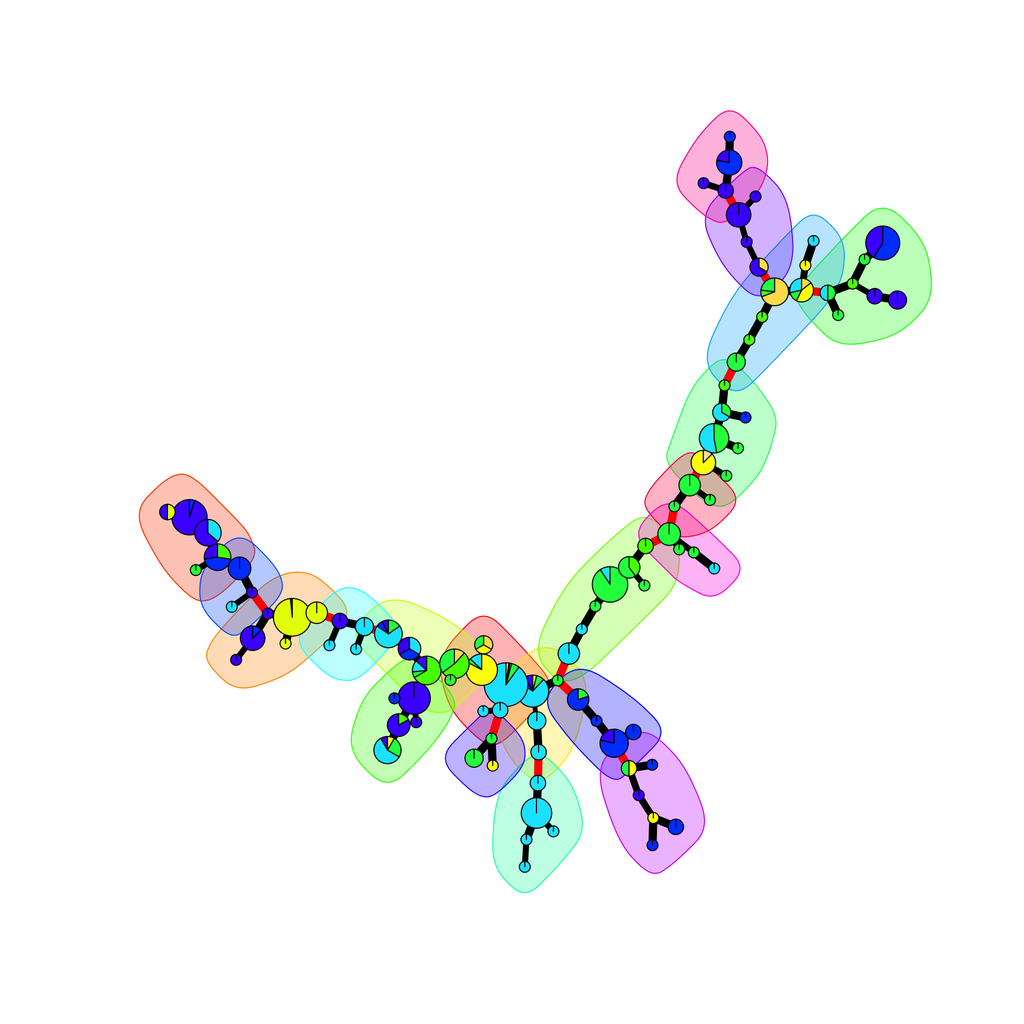

```r
plot(clusts, nf.msn$graph, vertex.size = log(V(nf.msn$graph)$size, 1.75) + 3,
     vertex.label = NA, layout = MASTER)
```